# Consequences of weather events in the US between 1950 and 2011

## SYNOPSIS

In this report, we are going to analyze NOAA database storm data, containing weather events and their consequences, for the populational damage, we consider the variables fatalities and injuries, while for the economic damage we use the property and crop damages. It was found that the events which caused most number of fatalities or injuries were Tornados, Excessive Heat and TSTM Wind. While Floods, Hurricanes and Tornados were the most damaging to the economy.

## DATA PROCESSING

Load the plyr and reshape packages to help with the data processing

```r
library(plyr)
library(reshape2)
```

Download NOAA Storm Database

```r
if (!file.exists("StormData.csv.bz2")){
    setInternet2(use = TRUE)
    download.file("https://d396qusza40orc.cloudfront.net/repdata%2Fdata%2FStormData.csv.bz2", "StormData.csv.bz2")
}
```

Read the data into storm_data variable

```r
storm_data <- read.csv(bzfile("StormData.csv.bz2"))
```

Normalize the economic data

```r
treated_data <- mutate(storm_data,
                       PROPDMG = (ifelse(toupper(PROPDMGEXP) == 'K', PROPDMG * 10^3,
                           ifelse(toupper(PROPDMGEXP) == 'M', PROPDMG * 10^6,
                           ifelse(toupper(PROPDMGEXP) == 'B', PROPDMG * 10^9,
                            PROPDMG)))
                           ))
treated_data <- mutate(treated_data,
                       CROPDMG = (ifelse(toupper(CROPDMGEXP) == 'K', CROPDMG * 10^3,
                           ifelse(toupper(CROPDMGEXP) == 'M', CROPDMG * 10^6,
                           ifelse(toupper(CROPDMGEXP) == 'B', CROPDMG * 10^9,
                            CROPDMG)))
                           ))
```

Aggregate the data by event type summing Fatalities And Injuries

```r
harmful_events <- aggregate(cbind(FATALITIES, INJURIES, PROPDMG, CROPDMG, FATALITIES + INJURIES, PROPDMG + CROPDMG) ~ EVTYPE, data = treated_data, sum)
names(harmful_events)[6] <- "POPDMG"
names(harmful_events)[7] <- "ECONDMG"
```

Gets the data from the 10 most harmful events for the population, give pretty names to the events and melt it to use as facets on the plot

```r
top_pop_damage <- head(harmful_events[order(harmful_events$POPDMG, decreasing = TRUE), c("EVTYPE", "FATALITIES", "INJURIES", "POPDMG")], 10)

names(top_pop_damage) <- c("Event", "Fatalities", "Injuries", "Total")

top_pop_damage_melted <- melt(data = top_pop_damage, id.vars = c("Event"))

top_pop_damage
```

```
##                 Event Fatalities Injuries Total
## 834           TORNADO       5633    91346 96979
## 130    EXCESSIVE HEAT       1903     6525  8428
## 856         TSTM WIND        504     6957  7461
## 170             FLOOD        470     6789  7259
## 464         LIGHTNING        816     5230  6046
## 275              HEAT        937     2100  3037
## 153       FLASH FLOOD        978     1777  2755
## 427         ICE STORM         89     1975  2064
## 760 THUNDERSTORM WIND        133     1488  1621
## 972      WINTER STORM        206     1321  1527
```

Gets the data from the 10 most harmful events for the economy, give pretty names to the events and melt it to use as facets on the plot

```r
top_economic_damage <- head(harmful_events[order(harmful_events$ECONDMG, decreasing = T), c("EVTYPE", "PROPDMG", "CROPDMG", "ECONDMG")], 10)

names(top_economic_damage) <- c("Event", "Property Damage", "Crop Damage", "Total")

top_economic_damage_melted <- melt(data = top_economic_damage, id.vars = c("Event"))

top_economic_damage
```

```
##                 Event Property Damage Crop Damage        Total
## 170             FLOOD    144657709807  5661968450 150319678257
## 411 HURRICANE/TYPHOON     69305840000  2607872800  71913712800
## 834           TORNADO     56937160779   414953270  57352114049
## 670       STORM SURGE     43323536000        5000  43323541000
## 244              HAIL     15732267048  3025954473  18758221521
## 153       FLASH FLOOD     16140812067  1421317100  17562129167
## 95            DROUGHT      1046106000 13972566000  15018672000
## 402         HURRICANE     11868319010  2741910000  14610229010
## 590       RIVER FLOOD      5118945500  5029459000  10148404500
## 427         ICE STORM      3944927860  5022113500   8967041360
```

## RESULTS

Loads the ggplot2 library for the plots

```r
library(ggplot2)
```

Displays the 10 most harmful population events

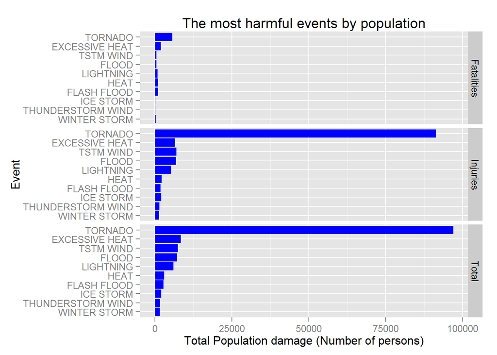

```r
ggplot(data = top_pop_damage_melted,
        aes(x = reorder(Event, value), y = value)) +
        facet_grid(variable ~ .) +
        coord_flip() +
        geom_bar(fill = "blue", stat = "identity") +
        xlab("Event") +
        ylab("Total Population damage (Number of persons)") +
        ggtitle("The most harmful events by population")
```

Tornadoes cause the largest number of deaths and injuries among the studied events. There are more than 5,000 deaths and more than 90,000 injuries in the last 60 years in US, due to tornadoes. Excessive heat and TSTM Wind follows on the list.

Displays the 10 most harmful economic events

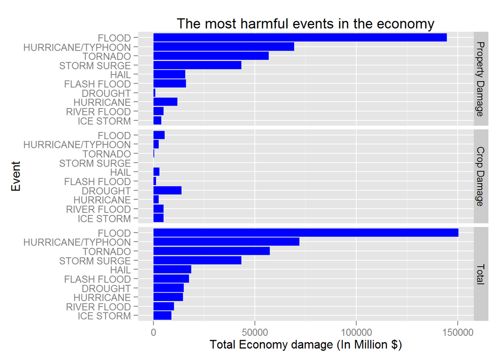

```r
ggplot(data = top_economic_damage_melted,
        aes(x = reorder(Event, value), y = (value/ 10 ^ 6))) +
        facet_grid(variable ~ .) +
        coord_flip() +
        geom_bar(fill = "blue", stat = "identity") +
        xlab("Event") +
        ylab("Total Economy damage (In Million $)") +
        ggtitle("The most harmful events in the economy")
```